# Bệnh đái tháo đường

```python
from PIL import Image
import matplotlib.pyplot as plt
image1 = Image.open("01.png"); image2 = Image.open("02.png"); image3 = Image.open("03.png");
```

## 1. Định nghĩa vấn đề (Problem)

-Mô tả: Đái tháo đường type 2 là một bệnh mạn tính ảnh hưởng nghiêm trọng đến sức khỏe cộng đồng. Việc phát hiện sớm có ý nghĩa quan trọng trong điều trị và phòng ngừa biến chứng. Tuy nhiên, quá trình chẩn đoán truyền thống thường tốn kém và mất thời gian. Vì vậy, cần có một mô hình dự đoán dựa trên dữ liệu y tế để hỗ trợ bác sĩ và bệnh nhân.

-Mục tiêu: Xây dựng mô hình học máy dự đoán khả năng mắc bệnh đái tháo đường ở bệnh nhân dựa trên các thông số lâm sàng.

-Dữ liệu sử dụng: Bộ dữ liệu gồm các đặc trưng y tế thu thập từ bệnh nhân:

+Pregnancies: Số lần mang thai.

+Glucose: Nồng độ glucose trong huyết tương sau khi uống dung dịch đường.

+BloodPressure: Huyết áp tâm trương (mm Hg).

+SkinThickness: Độ dày nếp gấp da (mm).

+Insulin: Nồng độ insulin huyết thanh (mu U/ml).

+BMI: Chỉ số khối cơ thể (kg/m²).

+DiabetesPedigreeFunction: Chỉ số di truyền liên quan đến nguy cơ đái tháo đường.

+Age: Tuổi bệnh nhân.

+Outcome: Nhãn đầu ra (1 = mắc bệnh đái tháo đường, 0 = không mắc).

-Kết quả mong đợi:

+Xây dựng mô hình phân loại để dự đoán giá trị Outcome (mắc bệnh hoặc không).

+Đánh giá mô hình bằng các chỉ số như Accuracy, Precision, Recall, F1-score.

+Mô hình có thể hỗ trợ y bác sĩ trong việc sàng lọc bệnh nhân, từ đó giúp phát hiện sớm và can thiệp kịp thời.

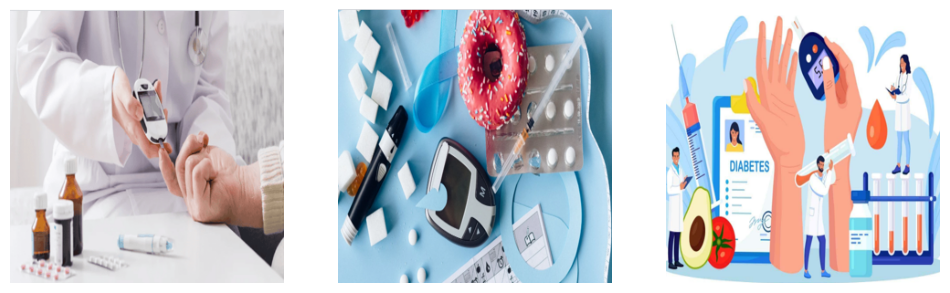

```python
plt.figure(figsize=(12,12));
plt.subplot(1,3,1), plt.imshow(image1.resize((300,300))), plt.axis("off");
plt.subplot(1,3,2), plt.imshow(image2.resize((300,300))), plt.axis("off");
plt.subplot(1,3,3), plt.imshow(image3.resize((300,300))), plt.axis("off");
plt.show()
```

## 2. Chuẩn bị vấn đề (Prepare problem)

### 2.1 Khai báo thư viện (Load Libraries)

```python
# Load libraries
import os, sys
from IPython import display
import numpy as np
import matplotlib.pyplot as plt
import pandas as pd
import seaborn as sns
import joblib

from sklearn.preprocessing import OneHotEncoder, LabelEncoder, OrdinalEncoder
from sklearn.preprocessing import MinMaxScaler, StandardScaler
from sklearn.model_selection import train_test_split

import warnings

%matplotlib inline
# plt.rcParams["figure.figsize"] = (12, 6)
# plt.rcParams['figure.dpi'] = 100

warnings.filterwarnings("ignore")
```

### 2.2. Nạp dữ liệu (Load Dataset)

```python
# Load dataset
data_path  = "data/diabetes.csv"
data_names = ["Pregnancies", "Glucose", "BloodPressure", "SkinThickness", "Insulin", "BMI", "DiabetesPedigreeFunction", "Age", "Outcome"]
df_dataset = pd.read_csv(data_path, names = data_names)
```

## 3. Phân tích dữ liệu (Analyze Data)

### 3.1. Thống kê mô tả (Descriptive Statistics)

#### (1) Hiển thị một số thông tin về dữ liệu

Số dòng, số cột của dữ liệu

Kiểu dữ liệu của từng cột

5 dòng đầu và 5 dòng cuối của bảng dữ liệu

Thông tin chung về dữ liệu

```python
# shape
print(f'+ Shape: {df_dataset.shape}')
# types
print(f'+ Data Types: \n{df_dataset.dtypes}')
# head, tail
print(f'+ Contents: ')
display.display(df_dataset.head(5))
display.display(df_dataset.tail(5))
# info
df_dataset.info()
```

```
+ Shape: (769, 9)
+ Data Types:
Pregnancies                 object
Glucose                     object
BloodPressure               object
SkinThickness               object
Insulin                     object
BMI                         object
DiabetesPedigreeFunction    object
Age                         object
Outcome                     object
dtype: object
+ Contents:
```

|  | Pregnancies | Glucose | BloodPressure | SkinThickness | Insulin | BMI | DiabetesPedigreeFunction | Age | Outcome |
| --- | --- | --- | --- | --- | --- | --- | --- | --- | --- |
| 0 | Pregnancies | Glucose | BloodPressure | SkinThickness | Insulin | BMI | DiabetesPedigreeFunction | Age | Outcome |
| 1 | 6 | 148 | 72 | 35 | 0 | 33.6 | 0.627 | 50 | 1 |
| 2 | 1 | 85 | 66 | 29 | 0 | 26.6 | 0.351 | 31 | 0 |
| 3 | 8 | 183 | 64 | 0 | 0 | 23.3 | 0.672 | 32 | 1 |
| 4 | 1 | 89 | 66 | 23 | 94 | 28.1 | 0.167 | 21 | 0 |

|  | Pregnancies | Glucose | BloodPressure | SkinThickness | Insulin | BMI | DiabetesPedigreeFunction | Age | Outcome |
| --- | --- | --- | --- | --- | --- | --- | --- | --- | --- |
| 764 | 10 | 101 | 76 | 48 | 180 | 32.9 | 0.171 | 63 | 0 |
| 765 | 2 | 122 | 70 | 27 | 0 | 36.8 | 0.34 | 27 | 0 |
| 766 | 5 | 121 | 72 | 23 | 112 | 26.2 | 0.245 | 30 | 0 |
| 767 | 1 | 126 | 60 | 0 | 0 | 30.1 | 0.349 | 47 | 1 |
| 768 | 1 | 93 | 70 | 31 | 0 | 30.4 | 0.315 | 23 | 0 |

```
<class 'pandas.core.frame.DataFrame'>
RangeIndex: 769 entries, 0 to 768
Data columns (total 9 columns):
 #   Column                    Non-Null Count  Dtype
---  ------                    --------------  -----
 0   Pregnancies               769 non-null    object
 1   Glucose                   769 non-null    object
 2   BloodPressure             769 non-null    object
 3   SkinThickness             769 non-null    object
 4   Insulin                   769 non-null    object
 5   BMI                       769 non-null    object
 6   DiabetesPedigreeFunction  769 non-null    object
 7   Age                       769 non-null    object
 8   Outcome                   769 non-null    object
dtypes: object(9)
memory usage: 54.2+ KB
```

**Nhận xét:**

-Dữ liệu có 769 bản ghi (records) và 9 thuộc tính (columns)

-Các cột gồm:

Pregnancies: số lần mang thai.

Glucose: nồng độ đường huyết.

BloodPressure: huyết áp tâm trương.

SkinThickness: độ dày da (mm).

Insulin: nồng độ insulin.

BMI: chỉ số khối cơ thể.

DiabetesPedigreeFunction: chỉ số nguy cơ dựa vào di truyền.

Age: tuổi.

Outcome: nhãn mục tiêu (0 = không mắc bệnh, 1 = mắc bệnh).

-Kiểu dữ liệu (Data Types): Hiện tại tất cả các cột đều có kiểu object thay vì số học (int, float).

-Điều này có thể do dữ liệu chứa:

Giá trị bị đọc nhầm (ví dụ: ký tự, khoảng trắng, NA…).

Dữ liệu số được lưu ở dạng chuỗi.

Cần chuyển đổi kiểu dữ liệu về số (int hoặc float) trước khi phân tích và huấn luyện mô hình.

#### (2) Kiểm tra tính toàn vẹn của dữ liệu

Dữ liệu có bị trùng lặp không? Hiển thị dòng bị vi phạm.

Dữ liệu có tồn tại giá trị Null không? Hiển thị dòng bị vi phạm.

Dữ liệu có tồn tại giá trị NaN không? Hiển thị dòng bị vi phạm

```python
has_null = df_dataset.isnull().sum().any()
has_nan  = df_dataset.isna().sum().any()
n_duplicated = df_dataset.duplicated().sum()
print(f'Tính toàn vẹn dữ liệu:')
print(f'+ Có giá trị Null: {has_null}')
if has_null:
    display.display(df_dataset[df_dataset.isnull().any(axis=1)])
print(f'+ Có giá trị Nan: {has_nan}')
if has_nan:
    display.display(df_dataset[df_dataset.isna().any(axis=1)])
print(f'+ Số dòng trùng: {n_duplicated}')
if n_duplicated>0:
    s_query1 = "`sepal-length`==4.9 and `sepal-width`==3.1 and `class`=='Iris-setosa'"
    s_query2 = "`sepal-length`==5.8 and `sepal-width`==2.7 and `class`=='Iris-virginica'"
    display.display(df_dataset.query(s_query1))
    display.display(df_dataset.query(s_query2))
    display.display(df_dataset[df_dataset.duplicated()])
```

```
Tính toàn vẹn dữ liệu:
+ Có giá trị Null: False
+ Có giá trị Nan: False
+ Số dòng trùng: 0
```

**Nhận xét:**

Dữ liệu không trùng

Dữ liệu không có giá trị rỗng (NaN, Null)

#### (3) Các tính chất thống kê trên dữ liệu số

Count, Mean, Standard Deviation, Minimum Value

25th Percentile, 50th Percentile (Median), 75th Percentile, Maximum Value

```python
description = df_dataset.describe().T
display.display(description)
```

|  | count | unique | top | freq |
| --- | --- | --- | --- | --- |
| Pregnancies | 769 | 18 | 1 | 135 |
| Glucose | 769 | 137 | 100 | 17 |
| BloodPressure | 769 | 48 | 70 | 57 |
| SkinThickness | 769 | 52 | 0 | 227 |
| Insulin | 769 | 187 | 0 | 374 |
| BMI | 769 | 249 | 32 | 13 |
| DiabetesPedigreeFunction | 769 | 518 | 0.258 | 6 |
| Age | 769 | 53 | 22 | 72 |
| Outcome | 769 | 3 | 0 | 500 |

**Nhận xét:**

Tất cả các biến đều có 769 giá trị, không có giá trị trống.

Một số biến có 0 xuất hiện nhiều lần, đặc biệt là SkinThickness (227 lần) và Insulin (374 lần), có thể phản ánh dữ liệu thiếu hoặc không đo được.

Ở biến Outcome, có 3 giá trị khác nhau thay vì 2, trong đó lớp 0 chiếm đa số (500/769) → dữ liệu bị mất cân bằng và có khả năng chứa giá trị bất thường.

#### (4) Mối tương quan giữa các tính chất (Correlations)

Sự tương quan (correlation) đề cập đến mối quan hệ giữa hai biến và cách chúng có thể có hoặc không cùng nhau thay đổi.

Phương pháp phổ biến nhất để tính toán tương quan là Pearson's Correlation Coeficient, giả định có một phân phối chuẩn của các thuộc tính liên quan. Tương quan -1 hoặc 1 cho thấy mối tương quan âm hoặc dương đầy đủ tương ứng. Trong khi giá trị 0 hiển thị không tương quan ở tất cả.

$$ r = \frac{\sum_{i=1}^{n} (x_i - \bar{x})(y_i - \bar{y})} {\sqrt{\sum_{i=1}^{n} (x_i - \bar{x})^2 \; \sum_{i=1}^{n} (y_i - \bar{y})^2}} $$

Một số thuật toán học máy như hồi quy tuyến tính và logistic có hiệu suất kém nếu có các thuộc tính tương quan cao trong tập dữ liệu của bạn.

Như vậy, thật sự cần thiết để xem xét tất cả các mối tương quan theo cặp của các thuộc tính trong tập dữ liệu.

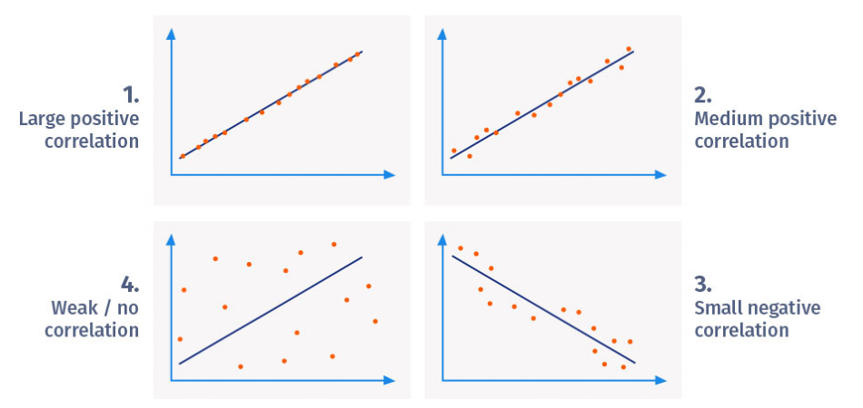

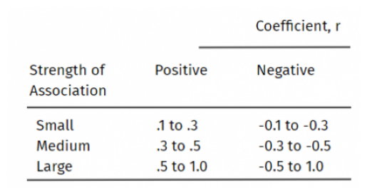

```python
plt.figure(figsize=(12, 6));
plt.imshow(plt.imread("corr1.png")), plt.axis("off"), plt.show();
plt.imshow(plt.imread("corr2.png")), plt.axis("off"), plt.show();
```

```python
# 1. Chuyển tất cả cột sang kiểu số
cols = ['Pregnancies','Glucose','BloodPressure','SkinThickness',
        'Insulin','BMI','DiabetesPedigreeFunction','Age','Outcome']
df_dataset[cols] = df_dataset[cols].apply(pd.to_numeric, errors='coerce')

# 2. Thay thế giá trị 0 bằng NaN cho những cột không hợp lý khi có 0
cols_with_zero_invalid = ['Glucose','BloodPressure','SkinThickness','Insulin','BMI']
df_dataset[cols_with_zero_invalid] = df_dataset[cols_with_zero_invalid].replace(0, np.nan)

# 3. Loại bỏ giá trị bất thường trong Outcome
df_dataset = df_dataset[df_dataset['Outcome'].isin([0,1])]

# 4. Điền giá trị thiếu bằng median
for col in cols_with_zero_invalid:
    df_dataset[col].fillna(df_dataset[col].median(), inplace=True)

# 5. Chuẩn hóa dữ liệu (Z-score)
scaler = StandardScaler()
df_scaled = df_dataset.copy()
df_scaled[cols[:-1]] = scaler.fit_transform(df_scaled[cols[:-1]])

print(df_scaled.head())
```

```
   Pregnancies   Glucose  BloodPressure  SkinThickness   Insulin       BMI  \
1     0.639947  0.866045      -0.031990       0.670643 -0.181541  0.166619
2    -0.844885 -1.205066      -0.528319      -0.012301 -0.181541 -0.852200
3     1.233880  2.016662      -0.693761      -0.012301 -0.181541 -1.332500
4    -0.844885 -1.073567      -0.528319      -0.695245 -0.540642 -0.633881
5    -1.141852  0.504422      -2.679076       0.670643  0.316566  1.549303

   DiabetesPedigreeFunction       Age  Outcome
1                  0.468492  1.425995      1.0
2                 -0.365061 -0.190672      0.0
3                  0.604397 -0.105584      1.0
4                 -0.920763 -1.041549      0.0
5                  5.484909 -0.020496      1.0
```

```python
correlations = df_dataset.corr(method='pearson')
display.display(correlations)
```

|  | Pregnancies | Glucose | BloodPressure | SkinThickness | Insulin | BMI | DiabetesPedigreeFunction | Age | Outcome |
| --- | --- | --- | --- | --- | --- | --- | --- | --- | --- |
| Pregnancies | 1.000000 | 0.128213 | 0.208615 | 0.081770 | 0.025047 | 0.021559 | -0.033523 | 0.544341 | 0.221898 |
| Glucose | 0.128213 | 1.000000 | 0.218937 | 0.192615 | 0.419451 | 0.231049 | 0.137327 | 0.266909 | 0.492782 |
| BloodPressure | 0.208615 | 0.218937 | 1.000000 | 0.191892 | 0.045363 | 0.281257 | -0.002378 | 0.324915 | 0.165723 |
| SkinThickness | 0.081770 | 0.192615 | 0.191892 | 1.000000 | 0.155610 | 0.543205 | 0.102188 | 0.126107 | 0.214873 |
| Insulin | 0.025047 | 0.419451 | 0.045363 | 0.155610 | 1.000000 | 0.180241 | 0.126503 | 0.097101 | 0.203790 |
| BMI | 0.021559 | 0.231049 | 0.281257 | 0.543205 | 0.180241 | 1.000000 | 0.153438 | 0.025597 | 0.312038 |
| DiabetesPedigreeFunction | -0.033523 | 0.137327 | -0.002378 | 0.102188 | 0.126503 | 0.153438 | 1.000000 | 0.033561 | 0.173844 |
| Age | 0.544341 | 0.266909 | 0.324915 | 0.126107 | 0.097101 | 0.025597 | 0.033561 | 1.000000 | 0.238356 |
| Outcome | 0.221898 | 0.492782 | 0.165723 | 0.214873 | 0.203790 | 0.312038 | 0.173844 | 0.238356 | 1.000000 |

**Ý nghĩa chỉ số**

Các giá trị dao động từ -1 → 1.

Gần 1: Tương quan thuận mạnh (cùng tăng/giảm).

Gần -1: Tương quan nghịch mạnh (một tăng, một giảm).

Gần 0: Tương quan yếu hoặc không đáng kể.

Đây là hệ số tương quan Pearson, đo lường mức độ tuyến tính giữa hai biến.

-Nhận xét

Outcome (mục tiêu) có tương quan mạnh nhất với:

Glucose (0.49) → đường huyết cao liên quan nhiều đến khả năng bị tiểu đường.

BMI (0.31) → chỉ số khối cơ thể cũng ảnh hưởng.

Age (0.24) → tuổi cao có khả năng mắc cao hơn.

Pregnancies (0.22) → số lần mang thai có liên hệ với tiểu đường.

Các biến khác tương quan thấp hơn.

Giữa các biến độc lập:

SkinThickness – BMI (0.54): khá mạnh, dễ hiểu vì da dày hơn thì BMI thường cao.

Glucose – Insulin (0.42): hợp lý, vì đường huyết và insulin có quan hệ sinh lý.

Age – Pregnancies (0.54): dễ hiểu, tuổi cao thì số lần mang thai thường nhiều hơn.

Một số cặp gần như không có tương quan:

Pregnancies – BMI (0.02)

BloodPressure – DiabetesPedigreeFunction (-0.00)

-Kết luận:

Biến dự đoán chính cho tiểu đường là Glucose, kế đến là BMI, Age, và Pregnancies.

Một số biến có tương quan cao với nhau (SkinThickness – BMI, Glucose – Insulin) → có thể gây đa cộng tuyến (multicollinearity) khi dùng mô hình hồi quy.

### 3.2. Hiển thị dữ liệu (Visualize Data)

#### (1) Hiển thị trên từng tính chất đơn (Univariate Plots)

So sánh các trung vị (median) tương ứng của mỗi ô hộp (box plot). Nếu đường trung vị của một ô hộp nằm bên ngoài ô của một ô hộp so sánh, thì có thể có sự khác biệt giữa hai nhóm.

So sánh chiều dài hộp để kiểm tra cách dữ liệu được phân tán giữa mỗi mẫu. Hộp càng dài thì dữ liệu càng phân tán. Dữ liệu càng nhỏ càng ít bị phân tán.

Một ngoại lệ (outlier) được định nghĩa là một điểm dữ liệu nằm bên ngoài phần rìa (whiskers) của ô hộp. Kiểm tra hướng lệch của dữ liệu (cân đối, các phần tử tập trung trái, phải).

Median ở giữa hộp và râu (whiskers) ở hai bên như nhau thì phân bố là đối xứng.

Median ở gần đáy hộp hơn và nếu râu ngắn hơn ở đầu dưới của hộp, thì phân phối là lệch dương (lệch phải).

Median ở gần đầu hộp hơn và nếu râu ngắn hơn ở đầu trên của hộp, thì phân bố bị lệch âm (lệch trái).

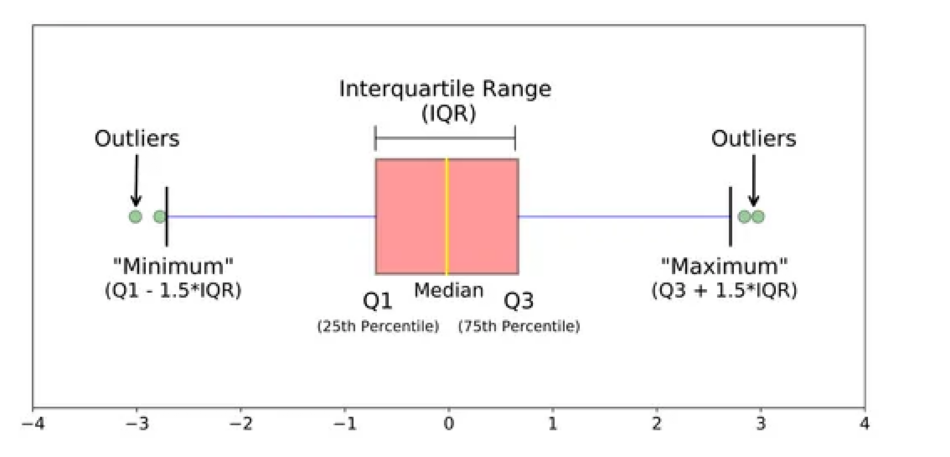

```python
plt.figure(figsize=(12, 6)), plt.imshow(plt.imread("boxplots.png")), plt.axis("off"), plt.show();
```

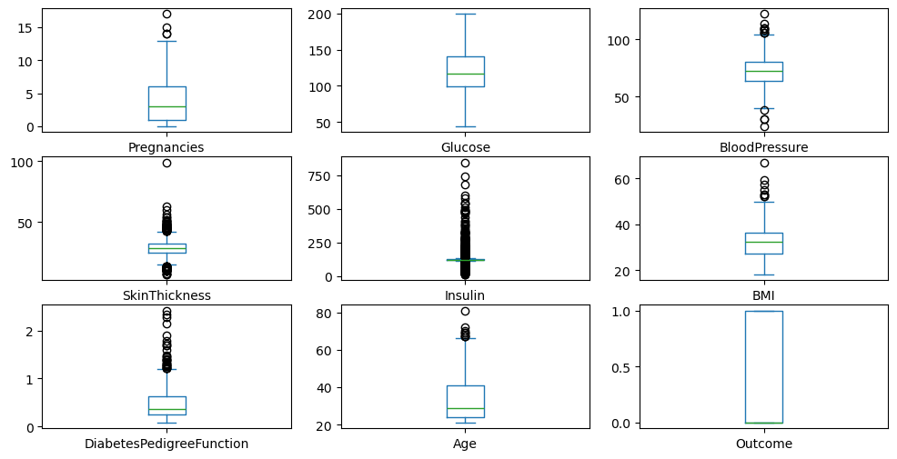

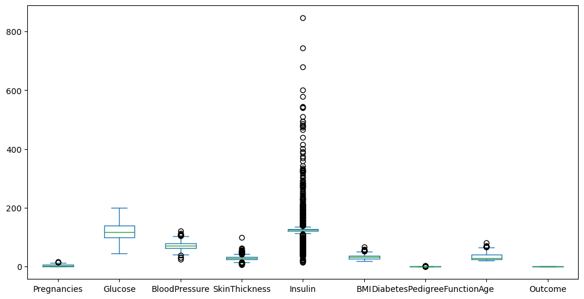

```python
df_dataset.plot(kind="box", subplots=True, layout=(3, 3), sharex=False, sharey=False, figsize=(12,6));
df_dataset.plot(kind="box", figsize=(12,6));
```

**Nhận xét:**

-Độ lệch không đều có nhiều giá trị ngoại lai

-Độ trải rộng giữa các tính chất khá khác nhau

[figure not shown]

```python
df_dataset.hist(figsize=(12, 6), bins = 20, sharex = True, sharey = True);
```

#### (2) Hiển thị nhiều tính chất (Multivariate Plots)

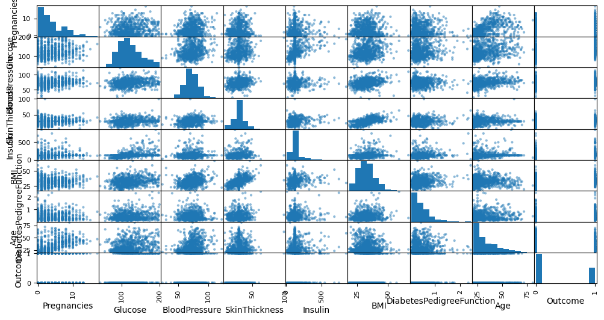

```python
pd.plotting.scatter_matrix(df_dataset, figsize=(12,6));
```

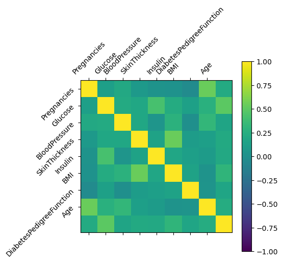

```python
plt.matshow(correlations, vmin=-1, vmax=1)
plt.colorbar()

ticks = np.arange(len(df_dataset.columns[:-1]))

plt.xticks(ticks, df_dataset.columns[:-1], rotation=45)
plt.yticks(ticks, df_dataset.columns[:-1], rotation=45)

plt.show()
```

## 4. Chuẩn bị dữ liệu (Prepare Data)

### 4.1. Làm sạch dữ liệu (Data Cleaning)

#### (1) Tạo bảng dữ liệu làm sạch

Chỉ giữ lại các cột Input, Ouput

```python
df_clean = df_dataset.copy()
```

#### (2) Xóa dữ liệu trùng nhau

```python
display.display(df_dataset[df_dataset.duplicated()])
```

|  | Pregnancies | Glucose | BloodPressure | SkinThickness | Insulin | BMI | DiabetesPedigreeFunction | Age | Outcome |
| --- | --- | --- | --- | --- | --- | --- | --- | --- | --- |

```python
df_clean.drop_duplicates(ignore_index=True, inplace=True)
df_clean
```

|  | Pregnancies | Glucose | BloodPressure | SkinThickness | Insulin | BMI | DiabetesPedigreeFunction | Age | Outcome |
| --- | --- | --- | --- | --- | --- | --- | --- | --- | --- |
| 0 | 6.0 | 148.0 | 72.0 | 35.0 | 125.0 | 33.6 | 0.627 | 50.0 | 1.0 |
| 1 | 1.0 | 85.0 | 66.0 | 29.0 | 125.0 | 26.6 | 0.351 | 31.0 | 0.0 |
| 2 | 8.0 | 183.0 | 64.0 | 29.0 | 125.0 | 23.3 | 0.672 | 32.0 | 1.0 |
| 3 | 1.0 | 89.0 | 66.0 | 23.0 | 94.0 | 28.1 | 0.167 | 21.0 | 0.0 |
| 4 | 0.0 | 137.0 | 40.0 | 35.0 | 168.0 | 43.1 | 2.288 | 33.0 | 1.0 |
| ... | ... | ... | ... | ... | ... | ... | ... | ... | ... |
| 763 | 10.0 | 101.0 | 76.0 | 48.0 | 180.0 | 32.9 | 0.171 | 63.0 | 0.0 |
| 764 | 2.0 | 122.0 | 70.0 | 27.0 | 125.0 | 36.8 | 0.340 | 27.0 | 0.0 |
| 765 | 5.0 | 121.0 | 72.0 | 23.0 | 112.0 | 26.2 | 0.245 | 30.0 | 0.0 |
| 766 | 1.0 | 126.0 | 60.0 | 29.0 | 125.0 | 30.1 | 0.349 | 47.0 | 1.0 |
| 767 | 1.0 | 93.0 | 70.0 | 31.0 | 125.0 | 30.4 | 0.315 | 23.0 | 0.0 |

768 rows × 9 columns

#### (3) Xử lý giá trị rỗng, không hợp lệ

```python
has_null = df_dataset.isnull().sum().any()
has_nan  = df_dataset.isna().sum().any()
print(f'+ Có giá trị Null: {has_null}')
if has_null:
    display.display(df_dataset[df_dataset.isnull().any(axis=1)])
print(f'+ Có giá trị Nan: {has_nan}')
if has_nan:
    display.display(df_dataset[df_dataset.isna().any(axis=1)])
```

```
+ Có giá trị Null: False
+ Có giá trị Nan: False
```

#### (4) Chuẩn hóa dữ liệu (Data Normalize)

Chuẩn hóa các tính chất để đưa về cùng một miền trị

**Min-Max Normalization**

$$ z = \frac{x - \min(x)}{\max(x) - \min(x)} $$

**Standard Normalization (Z-score)**

$$ z = \frac{x - \mu}{\sigma} $$

Lưu ý: Quá trình chuẩn hóa có thể làm trong phần thực nghiệm thuật toán

```python
scale_columns = ["Pregnancies", "Glucose", "BloodPressure",
                 "SkinThickness", "Insulin", "BMI",
                 "DiabetesPedigreeFunction", "Age"]

# khởi tạo Min-Max Scaler
minmax_scaler = MinMaxScaler()

# fit và transform
minmax_scaler.fit(df_dataset[scale_columns])

# tạo bản copy để giữ dữ liệu gốc
df_dataset_minmax = df_dataset.copy()

# gán lại dữ liệu đã chuẩn hóa
df_dataset_minmax[scale_columns] = minmax_scaler.transform(df_dataset[scale_columns])

# xem thử kết quả
print(df_dataset_minmax.head())
```

```
   Pregnancies   Glucose  BloodPressure  SkinThickness   Insulin       BMI  \
1     0.352941  0.670968       0.489796       0.304348  0.133413  0.314928
2     0.058824  0.264516       0.428571       0.239130  0.133413  0.171779
3     0.470588  0.896774       0.408163       0.239130  0.133413  0.104294
4     0.058824  0.290323       0.428571       0.173913  0.096154  0.202454
5     0.000000  0.600000       0.163265       0.304348  0.185096  0.509202

   DiabetesPedigreeFunction       Age  Outcome
1                  0.234415  0.483333      1.0
2                  0.116567  0.166667      0.0
3                  0.253629  0.183333      1.0
4                  0.038002  0.000000      0.0
5                  0.943638  0.200000      1.0
```

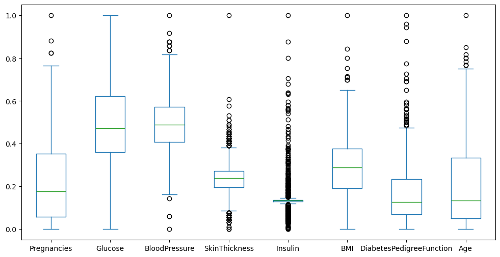

```python
df_dataset_minmax[scale_columns].plot(kind="box", figsize=(12,6));
```

```python
standard_scaler = StandardScaler()
standard_scaler.fit(df_clean[scale_columns])
df_clean_standard = df_clean.copy()
df_clean_standard[scale_columns] = standard_scaler.transform(df_clean[scale_columns])
df_clean_standard
```

|  | Pregnancies | Glucose | BloodPressure | SkinThickness | Insulin | BMI | DiabetesPedigreeFunction | Age | Outcome |
| --- | --- | --- | --- | --- | --- | --- | --- | --- | --- |
| 0 | 0.639947 | 0.866045 | -0.031990 | 0.670643 | -0.181541 | 0.166619 | 0.468492 | 1.425995 | 1.0 |
| 1 | -0.844885 | -1.205066 | -0.528319 | -0.012301 | -0.181541 | -0.852200 | -0.365061 | -0.190672 | 0.0 |
| 2 | 1.233880 | 2.016662 | -0.693761 | -0.012301 | -0.181541 | -1.332500 | 0.604397 | -0.105584 | 1.0 |
| 3 | -0.844885 | -1.073567 | -0.528319 | -0.695245 | -0.540642 | -0.633881 | -0.920763 | -1.041549 | 0.0 |
| 4 | -1.141852 | 0.504422 | -2.679076 | 0.670643 | 0.316566 | 1.549303 | 5.484909 | -0.020496 | 1.0 |
| ... | ... | ... | ... | ... | ... | ... | ... | ... | ... |
| 763 | 1.827813 | -0.679069 | 0.298896 | 2.150354 | 0.455573 | 0.064737 | -0.908682 | 2.532136 | 0.0 |
| 764 | -0.547919 | 0.011301 | -0.197433 | -0.239949 | -0.181541 | 0.632365 | -0.398282 | -0.531023 | 0.0 |
| 765 | 0.342981 | -0.021574 | -0.031990 | -0.695245 | -0.332132 | -0.910418 | -0.685193 | -0.275760 | 0.0 |
| 766 | -0.844885 | 0.142800 | -1.024647 | -0.012301 | -0.181541 | -0.342790 | -0.371101 | 1.170732 | 1.0 |
| 767 | -0.844885 | -0.942068 | -0.197433 | 0.215347 | -0.181541 | -0.299127 | -0.473785 | -0.871374 | 0.0 |

768 rows × 9 columns

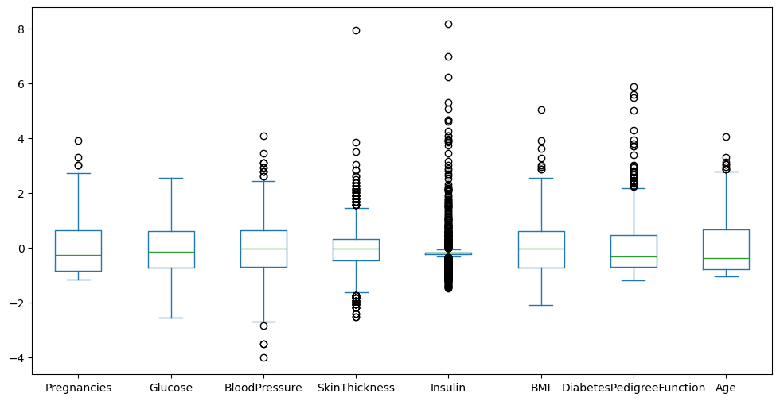

```python
df_clean_standard[scale_columns].plot(kind="box", figsize=(12,6));
```

```python
correlations = df_clean_standard.corr(method='pearson')
display.display(correlations)
```

|  | Pregnancies | Glucose | BloodPressure | SkinThickness | Insulin | BMI | DiabetesPedigreeFunction | Age | Outcome |
| --- | --- | --- | --- | --- | --- | --- | --- | --- | --- |
| Pregnancies | 1.000000 | 0.128213 | 0.208615 | 0.081770 | 0.025047 | 0.021559 | -0.033523 | 0.544341 | 0.221898 |
| Glucose | 0.128213 | 1.000000 | 0.218937 | 0.192615 | 0.419451 | 0.231049 | 0.137327 | 0.266909 | 0.492782 |
| BloodPressure | 0.208615 | 0.218937 | 1.000000 | 0.191892 | 0.045363 | 0.281257 | -0.002378 | 0.324915 | 0.165723 |
| SkinThickness | 0.081770 | 0.192615 | 0.191892 | 1.000000 | 0.155610 | 0.543205 | 0.102188 | 0.126107 | 0.214873 |
| Insulin | 0.025047 | 0.419451 | 0.045363 | 0.155610 | 1.000000 | 0.180241 | 0.126503 | 0.097101 | 0.203790 |
| BMI | 0.021559 | 0.231049 | 0.281257 | 0.543205 | 0.180241 | 1.000000 | 0.153438 | 0.025597 | 0.312038 |
| DiabetesPedigreeFunction | -0.033523 | 0.137327 | -0.002378 | 0.102188 | 0.126503 | 0.153438 | 1.000000 | 0.033561 | 0.173844 |
| Age | 0.544341 | 0.266909 | 0.324915 | 0.126107 | 0.097101 | 0.025597 | 0.033561 | 1.000000 | 0.238356 |
| Outcome | 0.221898 | 0.492782 | 0.165723 | 0.214873 | 0.203790 | 0.312038 | 0.173844 | 0.238356 | 1.000000 |

#### (5) Chia dữ liệu thực nghiệm

Chuyển đổi dữ liệu sang dạng numpy với phần Input (X_data), Output (y_data)

Chia dữ liệu thành tập train/test (tỷ lệ 70/30)

Lưu tất cả thông tin để chuẩn bị chạy thuật toán

```python
X_data, y_data = df_clean.values[:, :-1], df_clean.values[:, -1]
X_data.shape, y_data.shape
print(X_data[:20, :])
print(y_data[:20])
```

```
[[6.000e+00 1.480e+02 7.200e+01 3.500e+01 1.250e+02 3.360e+01 6.270e-01
  5.000e+01]
 [1.000e+00 8.500e+01 6.600e+01 2.900e+01 1.250e+02 2.660e+01 3.510e-01
  3.100e+01]
 [8.000e+00 1.830e+02 6.400e+01 2.900e+01 1.250e+02 2.330e+01 6.720e-01
  3.200e+01]
 [1.000e+00 8.900e+01 6.600e+01 2.300e+01 9.400e+01 2.810e+01 1.670e-01
  2.100e+01]
 [0.000e+00 1.370e+02 4.000e+01 3.500e+01 1.680e+02 4.310e+01 2.288e+00
  3.300e+01]
 [5.000e+00 1.160e+02 7.400e+01 2.900e+01 1.250e+02 2.560e+01 2.010e-01
  3.000e+01]
 [3.000e+00 7.800e+01 5.000e+01 3.200e+01 8.800e+01 3.100e+01 2.480e-01
  2.600e+01]
 [1.000e+01 1.150e+02 7.200e+01 2.900e+01 1.250e+02 3.530e+01 1.340e-01
  2.900e+01]
 [2.000e+00 1.970e+02 7.000e+01 4.500e+01 5.430e+02 3.050e+01 1.580e-01
  5.300e+01]
 [8.000e+00 1.250e+02 9.600e+01 2.900e+01 1.250e+02 3.230e+01 2.320e-01
  5.400e+01]
 [4.000e+00 1.100e+02 9.200e+01 2.900e+01 1.250e+02 3.760e+01 1.910e-01
  3.000e+01]
 [1.000e+01 1.680e+02 7.400e+01 2.900e+01 1.250e+02 3.800e+01 5.370e-01
  3.400e+01]
 [1.000e+01 1.390e+02 8.000e+01 2.900e+01 1.250e+02 2.710e+01 1.441e+00
  5.700e+01]
 [1.000e+00 1.890e+02 6.000e+01 2.300e+01 8.460e+02 3.010e+01 3.980e-01
  5.900e+01]
 [5.000e+00 1.660e+02 7.200e+01 1.900e+01 1.750e+02 2.580e+01 5.870e-01
  5.100e+01]
 [7.000e+00 1.000e+02 7.200e+01 2.900e+01 1.250e+02 3.000e+01 4.840e-01
  3.200e+01]
 [0.000e+00 1.180e+02 8.400e+01 4.700e+01 2.300e+02 4.580e+01 5.510e-01
  3.100e+01]
 [7.000e+00 1.070e+02 7.400e+01 2.900e+01 1.250e+02 2.960e+01 2.540e-01
  3.100e+01]
 [1.000e+00 1.030e+02 3.000e+01 3.800e+01 8.300e+01 4.330e+01 1.830e-01
  3.300e+01]
 [1.000e+00 1.150e+02 7.000e+01 3.000e+01 9.600e+01 3.460e+01 5.290e-01
  3.200e+01]]
[1. 0. 1. 0. 1. 0. 1. 0. 1. 1. 0. 1. 0. 1. 1. 1. 1. 1. 0. 1.]
```

```python
X_train, X_test, y_train, y_test = train_test_split(X_data, y_data, train_size=0.7)
print(f'+ Train/Test: Train Ratio = {len(X_train)/len(X_data)}')
print(f'+ Train: shape={X_train.shape}\nInput = \n{X_train[:5]}\nOutput = {y_train[:5]}')
print(f'+ Test: shape={X_test.shape}\nInput = \n{X_test[:5]}\nOutput = {y_test[:5]}')
```

```
+ Train/Test: Train Ratio = 0.69921875
+ Train: shape=(537, 8)
Input =
[[8.00e+00 1.26e+02 7.40e+01 3.80e+01 7.50e+01 2.59e+01 1.62e-01 3.90e+01]
 [0.00e+00 1.31e+02 8.80e+01 2.90e+01 1.25e+02 3.16e+01 7.43e-01 3.20e+01]
 [0.00e+00 1.31e+02 7.20e+01 2.90e+01 1.25e+02 4.32e+01 2.70e-01 2.60e+01]
 [9.00e+00 7.20e+01 7.80e+01 2.50e+01 1.25e+02 3.16e+01 2.80e-01 3.80e+01]
 [1.00e+00 1.67e+02 7.40e+01 1.70e+01 1.44e+02 2.34e+01 4.47e-01 3.30e+01]]
Output = [0. 1. 1. 0. 1.]
+ Test: shape=(231, 8)
Input =
[[0.00e+00 1.14e+02 8.00e+01 3.40e+01 2.85e+02 4.42e+01 1.67e-01 2.70e+01]
 [0.00e+00 1.80e+02 9.00e+01 2.60e+01 9.00e+01 3.65e+01 3.14e-01 3.50e+01]
 [5.00e+00 1.24e+02 7.40e+01 2.90e+01 1.25e+02 3.40e+01 2.20e-01 3.80e+01]
 [2.00e+00 9.00e+01 6.80e+01 4.20e+01 1.25e+02 3.82e+01 5.03e-01 2.70e+01]
 [1.00e+00 1.35e+02 5.40e+01 2.90e+01 1.25e+02 2.67e+01 6.87e-01 6.20e+01]]
Output = [0. 1. 1. 1. 0.]
```

```python
save_dir = "exps/diabetes"
if not os.path.exists(save_dir):
    os.makedirs(save_dir)

# Save training data
np.savez(f'{save_dir}/data.npz',
         X_train=X_train, X_test=X_test,
         y_train=y_train, y_test=y_test)

# Save cleaned data
df_clean.to_excel(f'{save_dir}/df_clean.xlsx', index=False)

# Kiểm tra thư mục
print("Danh sách file trong thư mục:", os.listdir(save_dir))
```

```
Danh sách file trong thư mục: ['data.npz', 'df_clean.xlsx']
```

```python
# Kiểm tra phục hồi dữ liệu
dict(np.load(f'{save_dir}/data.npz')).keys()
```

```
dict_keys(['X_train', 'X_test', 'y_train', 'y_test'])
```

```python
pd.read_excel(f'{save_dir}/df_clean.xlsx')
```

|  | Pregnancies | Glucose | BloodPressure | SkinThickness | Insulin | BMI | DiabetesPedigreeFunction | Age | Outcome |
| --- | --- | --- | --- | --- | --- | --- | --- | --- | --- |
| 0 | 6 | 148 | 72 | 35 | 125 | 33.6 | 0.627 | 50 | 1 |
| 1 | 1 | 85 | 66 | 29 | 125 | 26.6 | 0.351 | 31 | 0 |
| 2 | 8 | 183 | 64 | 29 | 125 | 23.3 | 0.672 | 32 | 1 |
| 3 | 1 | 89 | 66 | 23 | 94 | 28.1 | 0.167 | 21 | 0 |
| 4 | 0 | 137 | 40 | 35 | 168 | 43.1 | 2.288 | 33 | 1 |
| ... | ... | ... | ... | ... | ... | ... | ... | ... | ... |
| 763 | 10 | 101 | 76 | 48 | 180 | 32.9 | 0.171 | 63 | 0 |
| 764 | 2 | 122 | 70 | 27 | 125 | 36.8 | 0.340 | 27 | 0 |
| 765 | 5 | 121 | 72 | 23 | 112 | 26.2 | 0.245 | 30 | 0 |
| 766 | 1 | 126 | 60 | 29 | 125 | 30.1 | 0.349 | 47 | 1 |
| 767 | 1 | 93 | 70 | 31 | 125 | 30.4 | 0.315 | 23 | 0 |

768 rows × 9 columns